# Week 13 Assignment

Jerri Berry Danso

April 21, 2025

In this homework, we will work with text gathered from a recent class recording. When Zoom records, it collects a transcript with time stamps and speaker identifiers. Before beginning, please download the Zoom data file(s) from Canvas and save them in a separate folder.

## Step 1

Load the tidyverse package. We will also use the tidytext package. Install and load this package if you have not already done so.

```r
library(tidyverse)
library(tidytext)
```

## Step 2

Let’s start by working with some text. Here’s an example that captures the core steps.

```r
my_sentences <- tibble(sentences = c("I think that she's really good at playing soccer, but he's probably a better dancer, especially at his age", "I really like to watch soccer games, especially for OneKnox", "She was a great goalkeeper, perhaps because she played soccer from such a young age"))

my_sentences %>%
  unnest_tokens(word, sentences) %>% # separate words, removing punctuation
  count(word) %>% # counting words
  arrange(desc(n)) %>% # arranging by frequency
  anti_join(stop_words) # removing common words, or "stop" words
```

```
## # A tibble: 9 × 2
##   word           n
##   <chr>      <int>
## 1 soccer         3
## 2 age            2
## 3 dancer         1
## 4 games          1
## 5 goalkeeper     1
## 6 oneknox        1
## 7 played         1
## 8 playing        1
## 9 watch          1
```

Before moving on to analyzing class data, what do you think are two benefits of analyzing text data in your field?

- In my field, text analysis helps uncover dominant themes in qualitative feedback, which can inform programmatic improvements.
- It can also enable evaluators to detect patterns in stakeholder sentiment or engagement over time.

## Step 3

Now, let’s do the same with our Zoom data.

```r
# First, read the class Zoom transcript CSV data. You can download this from Canvas!

transcript <- read_csv("processed-transcript_1.csv")
# In this next step, use similar code from Step 2.
transcript %>%
  unnest_tokens(word, text) %>%
  count(word) %>%
  arrange(desc(n)) %>%
  anti_join(stop_words)
```

```
## # A tibble: 861 × 2
##    word         n
##    <chr>    <int>
##  1 text       167
##  2 data       144
##  3 words       70
##  4 analysis    58
##  5 column      46
##  6 word        42
##  7 tidy        41
##  8 tokens      32
##  9 gonna       29
## 10 yeah        29
## # ℹ 851 more rows
```

Does looking at the top 10 words spoken in class give you an idea of what the class is about? Or any other meaningful information about the interactions that occurred?

- Words like “data,” “analysis,” and “tokens” offer indicators of the course’s content, suggesting a focus on data science or text analysis. In contrast, more generic terms such as “text,” “column,” and “word” could apply to a range of contexts and therefore provide less specificity. Informal words like “gonna” and “yeah” suggest conversational dynamics, possibly reflecting classroom interactions, student engagement, or verbal affirmations during the session.

## Step 4

Let’s create a column chart of the top words, styling it and making it easier to interpret by using color to enhance the plot. Please use a color package other than the default color and include axis titles. You may have to use `slice()` to make the graph clearer.

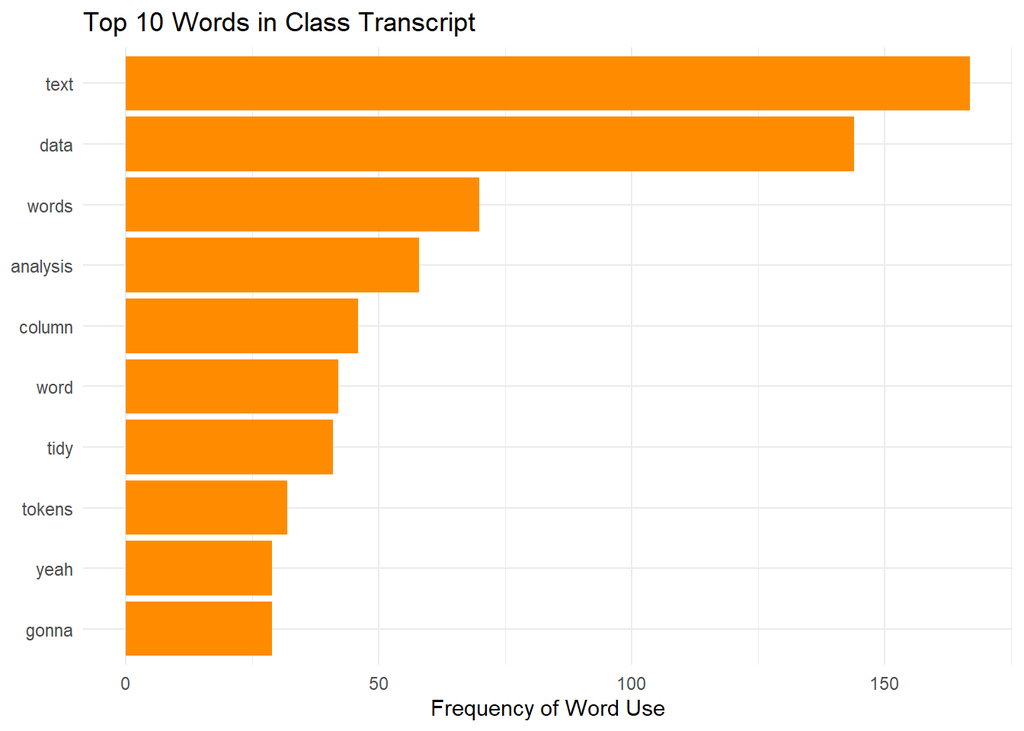

```r
library(ggplot2)
library(forcats)

#prep data
top_words_plot <- transcript %>%
  unnest_tokens(word, text) %>%
  anti_join(stop_words, by = "word") %>%
  count(word, sort = TRUE) %>%
  filter(n > 28) %>%
  mutate(word = fct_reorder(word, n))

#create column chart
ggplot(top_words_plot, aes(n, word)) +
  geom_col(fill = "darkorange") +
  labs(
    title = "Top 10 Words in Class Transcript",
    x = "Frequency of Word Use",
    y = NULL
  ) +
  theme_minimal()
```

## Step 5

Calculate the mean duration of the time spoken, then create a plot, coloring the points by the number of times each individual spoke. Be sure to include axis titles.

```r
mean_utterance_duration_and_n_utterances <- transcript %>%
    mutate(utterance_duration = end - start) %>%
  group_by(name) %>%
  summarize(mean_utterance_duration = mean(utterance_duration),
            n_utterances = n()) %>%
  arrange(desc(mean_utterance_duration))
```

```
## Defaulting to continuous.
```

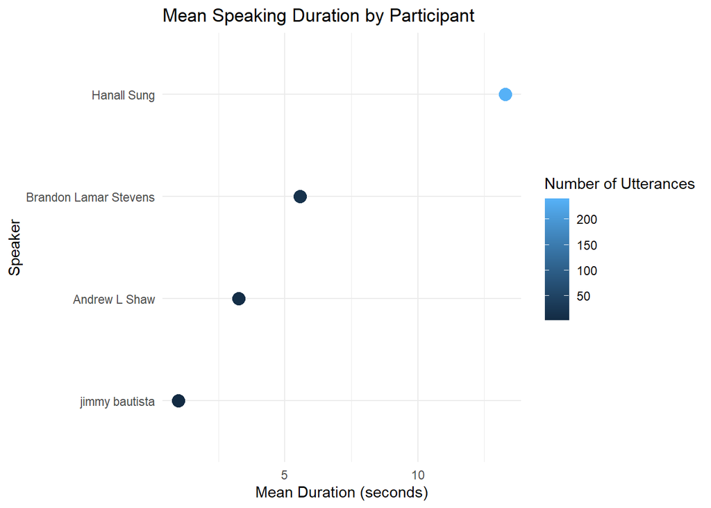

```r
# Use this code chunk for the plot

ggplot(mean_utterance_duration_and_n_utterances, aes(x = reorder(name, mean_utterance_duration), y = mean_utterance_duration, color = n_utterances)) +
  geom_point(size = 4) +
  coord_flip() +
  labs(
    title = "Mean Speaking Duration by Participant",
    x = "Speaker",
    y = "Mean Duration (seconds)",
    color = "Number of Utterances"
  ) +
  theme_minimal()
```

Who spoke the most? Does this result surprise you?

- The person who spoke the most was the course instructor, so this result does not surprise me.

If someone not associated with the class were given your graph, what do you think they would interpret about interactions in the class?

- Someone unfamiliar with the class might interpret the graph as evidence of low student engagement, given that only three students appeared to speak during the session. However, this snapshot may not fully reflect the broader class dynamics across the semester. The transcript does not capture interactions that occurred in breakout rooms or during other sessions, so it provides only a partial view of overall participation.

## Step 6

In this step, determine how many times the instructor spoke the word “data” over the class. Hint: use code similar to Steps 2 and 3. As a reach, calculate the mean number of “data” words per minute spoken (you may need to use the package lubridate).

```r
## of times instructor said "data"
data_mentions <- transcript %>%
  filter(name == "Hanall Sung") %>%
  unnest_tokens(word, text) %>%
  filter(word == "data") %>%
  nrow()
data_mentions
```

```
## [1] 143
```

```r
## The instructor spoke the word "data" 143 times during the course of the class.
## I did not attempt the "reach" component of Step 6, as I am not sure how to extract the words spoken per minute. I would have used step 5 as an example, but I am not sure what the unit of analysis is from step 5.
```

## Ethics

What could be an ethical concern with presenting the Zoom data as it was given to you? (e.g., the inclusion of screen names, etc.)

- One concern is the use of real names or screen names that could reveal identities without explicit consent.

What ethical concerns might be present when sharing word frequencies to a large audience?

- Frequencies can be misinterpreted or taken out of context, leading to inaccurate conclusions about individual behavior.

What is one other ethical concern you have with text/transcript data?

- Text data might capture sensitive comments or tone that could be misunderstood or used inappropriately if decontextualized.

## Reach

As a reach, conduct a sentiment analysis on the Zoom transcript data from class. To see code on how to do this, visit: https://www.tidytextmining.com/sentiment

```r
bing_sentiments <- get_sentiments("bing")

sentiment_data <- transcript %>%
  unnest_tokens(word, text) %>%
  inner_join(bing_sentiments) %>%
  count(sentiment) %>%
  arrange(desc(n))
```

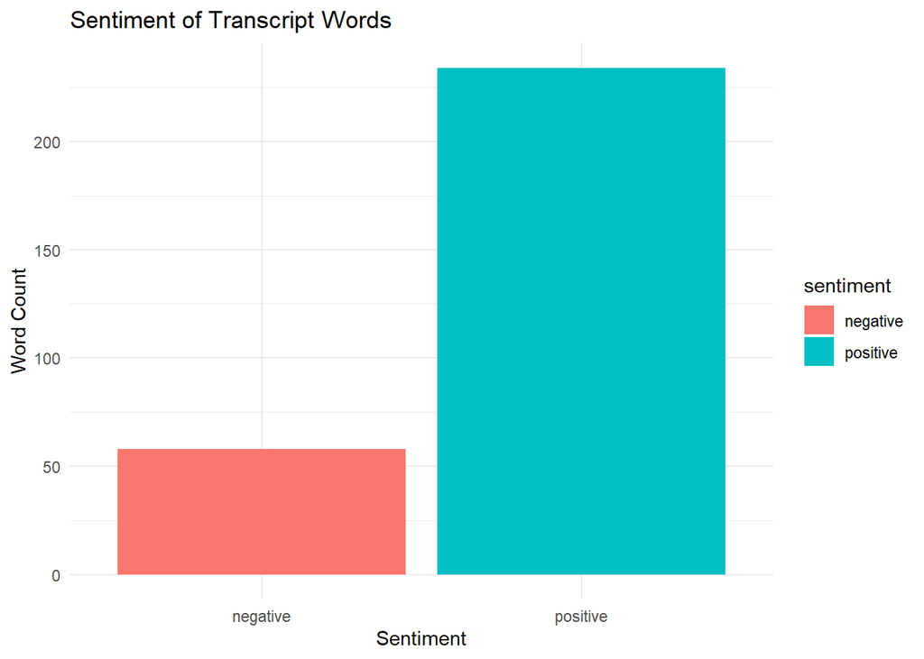

```r
ggplot(sentiment_data, aes(x = sentiment, y = n, fill = sentiment)) +
  geom_col() +
  labs(
    title = "Sentiment of Transcript Words",
    x = "Sentiment",
    y = "Word Count"
  ) +
  theme_minimal()
```

## Rubric

|  | Points Possible | Points Earned |
| --- | --- | --- |
| File knits | 2 |  |
| Code is accurately filled in for all 6 steps. | 10 |  |
| Step 2 Question | 3 |  |
| Step 3 Questions | 3 |  |
| Step 5 Question | 3 |  |
| Ethics Questions (3 points each) | 9 |  |

## Knit and Submit

Complete the following steps to knit and publish your work:

1. First, change the name of the `author:` in the [YAML header](https://bookdown.org/yihui/rmarkdown-cookbook/rmarkdown-anatomy.html#yaml-metadata) at the very top of this document to your name. The YAML header controls the style and feel for knitted document but doesn’t actually display in the final output.
2. Next, click the knit button in the toolbar above to “knit” your R Markdown document to a [HTML](https://bookdown.org/yihui/rmarkdown/html-document.html) file that will be saved in your R Project folder. You should see a formatted webpage appear in your Viewer tab in the lower right pan or in a new browser window. Let’s us know if you run into any issues with knitting.
3. Upload the HTML file that is now present in the same folder as this R Markdown file to Canvas to receive credit for this assignment!